# EDA for Customer Reviews

## Model 1 Decisions/Parameters Record

- **Target labels**
  - `starRating` kept as ordinal classes (**ONE – FIVE**) and mapped to a 3-way sentiment label:
  - `neg` = stars 1–2
  - `neu` = star 3
  - `pos` = stars 4–5
- **Text field**
  - Use only the English portion of `review_clean`, discarding original-language text segments.
  - Normalize text: lowercasing, accent removal, punctuation and extra-whitespace cleanup.
- **Modeling approach**
  - First model: TF-IDF features + linear classifier (e.g., logistic regression or linear SVM).
  - Later: optional experiment with compact transformer (e.g., DistilBERT).
- **NLP preprocessing**
  - Custom, light English stopword list that keeps negations and intensifiers (e.g., "not", "never", "very").
  - Lemmatization (English, preferably spaCy `en_core_web_sm` / `md`), no stemming.
- **Time features from `createTime`**
  - Parse as datetime.
  - Derive: year, month, day, day of week, hour, and optionally “year-month” period.
- **Handling missing/short reviews**
  - Drop rows where `review_clean` is empty or null after cleaning.
  - Keep short reviews; add flags: number of characters, number of words, and a binary `is_short` (e.g., `< 5 words`).

#### Step 1 – Imports and basic loading

```python
!pip install textacy
```

```
Downloading textacy-0.13.0-py3-none-any.whl (210 kB)
   ━━━━━━━━━━━━━━━━━━━━━━━━━━━━━━━━━━━━━━━━ 210.7/210.7 kB 5.6 MB/s eta 0:00:00
Downloading cytoolz-1.1.0-cp312-cp312-manylinux2014_x86_64.manylinux_2_17_x86_64.manylinux_2_28_x86_64.whl (2.9 MB)
   ━━━━━━━━━━━━━━━━━━━━━━━━━━━━━━━━━━━━━━━━ 2.9/2.9 MB 45.1 MB/s eta 0:00:00
Downloading floret-0.10.5-cp312-cp312-manylinux_2_17_x86_64.manylinux2014_x86_64.whl (321 kB)
   ━━━━━━━━━━━━━━━━━━━━━━━━━━━━━━━━━━━━━━━━ 321.6/321.6 kB 26.8 MB/s eta 0:00:00
Downloading jellyfish-1.2.1-cp312-cp312-manylinux_2_17_x86_64.manylinux2014_x86_64.whl (360 kB)
   ━━━━━━━━━━━━━━━━━━━━━━━━━━━━━━━━━━━━━━━━ 360.5/360.5 kB 27.0 MB/s eta 0:00:00
Downloading pyphen-0.17.2-py3-none-any.whl (2.1 MB)
   ━━━━━━━━━━━━━━━━━━━━━━━━━━━━━━━━━━━━━━━━ 2.1/2.1 MB 80.6 MB/s eta 0:00:00
```

```python
import pandas as pd
import numpy as np
import re
import unicodedata

from sklearn.model_selection import train_test_split
from sklearn.feature_extraction.text import TfidfVectorizer
from sklearn.linear_model import LogisticRegression
from sklearn.pipeline import Pipeline
from sklearn.metrics import classification_report, confusion_matrix
```

```python
from google.colab import userdata
token = userdata.get('GITHUB_TOKEN')
```

```python
# Use it with !wget to load the dataset from GitHub
!wget --header="Authorization: token {token}" https://raw.githubusercontent.com/lucaiaco21/Cafe-Madrid---TFM-Project/main/2.Comprension_de_los_datos_ETL/Datos_resenas/Reviews_EN.csv -O Reviews_EN.csv
```

```
--2026-02-12 16:40:14--  https://raw.githubusercontent.com/lucaiaco21/Cafe-Madrid---TFM-Project/main/2.Comprension_de_los_datos_ETL/Datos_resenas/Reviews_EN.csv
Resolving raw.githubusercontent.com (raw.githubusercontent.com)... 185.199.110.133, 185.199.109.133, 185.199.108.133, ...
Connecting to raw.githubusercontent.com (raw.githubusercontent.com)|185.199.110.133|:443... connected.
HTTP request sent, awaiting response... 200 OK
Length: 980396 (957K) [text/plain]
Saving to: ‘Reviews_EN.csv’

Reviews_EN.csv      100%[===================>] 957.42K  --.-KB/s    in 0.05s

2026-02-12 16:40:14 (19.1 MB/s) - ‘Reviews_EN.csv’ saved [980396/980396]
```

```python
# Adjust path as needed
df = pd.read_csv("Reviews_EN.csv")

# Restrict to needed columns
df = df[["createTime", "starRating", "review_clean"]]
```

```python
df
```

|  | createTime | starRating | review_clean |
| --- | --- | --- | --- |
| 0 | 2018-02-24T16:23:44.530Z | FIVE | (Translated by Google) Very welcoming place wi... |
| 1 | 2019-09-29T18:47:10.530323Z | FIVE | (Translated by Google) We stopped by for coffe... |
| 2 | 2019-09-24T19:01:11.659349Z | FOUR | NaN |
| 3 | 2019-09-23T17:26:48.376177Z | FOUR | Good coffee and cake, but heavy traffic an arm... |
| 4 | 2019-09-15T15:50:20.745042Z | FOUR | (Translated by Google) Good place for breakfas... |
| ... | ... | ... | ... |
| 2505 | 2025-10-16T20:02:51.675736Z | FIVE | (Translated by Google) Very comfortable, good ... |
| 2506 | 2025-10-16T07:09:26.980652Z | FIVE | (Translated by Google) The best coffee! If you... |
| 2507 | 2025-10-14T09:06:26.383063Z | FIVE | (Translated by Google) Breakfast with ham, ver... |
| 2508 | 2025-10-14T09:04:45.542688Z | FIVE | (Translated by Google) Phenomenal exquisite br... |
| 2509 | 2025-10-13T09:32:46.028701Z | FIVE | Love this place. Stop for breakfast every sing... |

2510 rows × 3 columns

#### Step 2 – Clean and encode starRating

```python
# Ensure starRating is standardized
print(df["starRating"].value_counts(dropna=False))

star_map = {
    "ONE": 1,
    "TWO": 2,
    "THREE": 3,
    "FOUR": 4,
    "FIVE": 5,
}

df["star_num"] = df["starRating"].map(star_map)

# 3‑way sentiment label
def map_sentiment(star):
    if pd.isna(star):
        return np.nan
    if star <= 2:
        return "neg"
    elif star == 3:
        return "neu"
    else:
        return "pos"

df["sentiment_3way"] = df["star_num"].apply(map_sentiment)
print(df["sentiment_3way"].value_counts(dropna=False))

# Drop rows with missing label
#df = df.dropna(subset=["star_num", "sentiment_3way"])
```

```
starRating
FIVE     1588
FOUR      497
THREE     228
ONE       113
TWO        84
Name: count, dtype: int64
sentiment_3way
pos    2085
neu     228
neg     197
Name: count, dtype: int64
```

```python
df[df['sentiment_3way'] == 'neg']
```

|  | createTime | starRating | review_clean | star_num | sentiment_3way |
| --- | --- | --- | --- | --- | --- |
| 13 | 2019-07-16T21:41:44.206395Z | TWO | (Translated by Google) Its location makes pric... | 2 | neg |
| 18 | 2019-06-09T16:02:14.527328Z | TWO | NaN | 2 | neg |
| 26 | 2024-07-20T10:51:17.135019Z | ONE | NaN | 1 | neg |
| 30 | 2024-07-11T18:31:07.566390Z | ONE | (Translated by Google) I've always liked it. B... | 1 | neg |
| 33 | 2024-07-02T10:07:55.300483Z | ONE | (Translated by Google) Very expensive for very... | 1 | neg |
| ... | ... | ... | ... | ... | ... |
| 2465 | 2022-11-19T07:32:14.017018Z | ONE | (Translated by Google) I'm giving one star not... | 1 | neg |
| 2467 | 2022-11-15T10:12:47.604216Z | ONE | (Translated by Google) Poor customer service\n... | 1 | neg |
| 2492 | 2025-11-03T19:23:38.809640Z | TWO | NaN | 2 | neg |
| 2493 | 2025-11-02T14:05:17.943870Z | ONE | (Translated by Google) The coffee is very very... | 1 | neg |
| 2494 | 2025-10-31T08:06:02.137307Z | TWO | NaN | 2 | neg |

197 rows × 5 columns

#### Step 3 – Parse createTime and derive time features

```python
# 1. Convert to datetime
df["createTime"] = pd.to_datetime(df["createTime"], errors="coerce", utc=True)

# 2. Drop rows AND create an independent copy (The Fix!)
df = df.dropna(subset=["createTime"]).copy()

# 3. Now these will run without any warnings
df["year"] = df["createTime"].dt.year
df["month"] = df["createTime"].dt.month
df["day"] = df["createTime"].dt.day
df["dayofweek"] = df["createTime"].dt.dayofweek
df["hour"] = df["createTime"].dt.hour

# 4. Handle the timezone warning for year_month
# .to_period() doesn't like timezones, so we strip it with .dt.tz_localize(None)
df["year_month"] = df["createTime"].dt.tz_localize(None).dt.to_period("M").astype(str)
```

#### Step 4 – Extract English portion of review_clean

```python
def extract_english(text):
    if pd.isna(text):
        return np.nan
    s = str(text)
    # If there is a translated segment marker
    if "(Translated by Google)" in s:
        # Take part after marker
        part = s.split("(Translated by Google)", 1)[1]
        # If "(Original)" appears later, cut before it
        if "(Original)" in part:
            part = part.split("(Original)", 1)[0]
        return part.strip()
    # If no marker, assume the whole text is already in English
    return s.strip()

df["text_en_raw"] = df["review_clean"].apply(extract_english)
```

```python
df
```

|  | createTime | starRating | review_clean | star_num | sentiment_3way | year | month | day | dayofweek | hour | year_month | text_en_raw |
| --- | --- | --- | --- | --- | --- | --- | --- | --- | --- | --- | --- | --- |
| 0 | 2018-02-24 16:23:44.530000+00:00 | FIVE | (Translated by Google) Very welcoming place wi... | 5 | pos | 2018 | 2 | 24 | 5 | 16 | 2018-02 | Very welcoming place with quality products at ... |
| 1 | 2019-09-29 18:47:10.530323+00:00 | FIVE | (Translated by Google) We stopped by for coffe... | 5 | pos | 2019 | 9 | 29 | 6 | 18 | 2019-09 | We stopped by for coffee. We were several frie... |
| 2 | 2019-09-24 19:01:11.659349+00:00 | FOUR | NaN | 4 | pos | 2019 | 9 | 24 | 1 | 19 | 2019-09 | NaN |
| 3 | 2019-09-23 17:26:48.376177+00:00 | FOUR | Good coffee and cake, but heavy traffic an arm... | 4 | pos | 2019 | 9 | 23 | 0 | 17 | 2019-09 | Good coffee and cake, but heavy traffic an arm... |
| 4 | 2019-09-15 15:50:20.745042+00:00 | FOUR | (Translated by Google) Good place for breakfas... | 4 | pos | 2019 | 9 | 15 | 6 | 15 | 2019-09 | Good place for breakfast, although the prices ... |
| ... | ... | ... | ... | ... | ... | ... | ... | ... | ... | ... | ... | ... |
| 2505 | 2025-10-16 20:02:51.675736+00:00 | FIVE | (Translated by Google) Very comfortable, good ... | 5 | pos | 2025 | 10 | 16 | 3 | 20 | 2025-10 | Very comfortable, good treatment |
| 2506 | 2025-10-16 07:09:26.980652+00:00 | FIVE | (Translated by Google) The best coffee! If you... | 5 | pos | 2025 | 10 | 16 | 3 | 7 | 2025-10 | The best coffee! If you want an extra-large co... |
| 2507 | 2025-10-14 09:06:26.383063+00:00 | FIVE | (Translated by Google) Breakfast with ham, ver... | 5 | pos | 2025 | 10 | 14 | 1 | 9 | 2025-10 | Breakfast with ham, very good, recommended qua... |
| 2508 | 2025-10-14 09:04:45.542688+00:00 | FIVE | (Translated by Google) Phenomenal exquisite br... | 5 | pos | 2025 | 10 | 14 | 1 | 9 | 2025-10 | Phenomenal exquisite breakfasts🥰🥰🥰 |
| 2509 | 2025-10-13 09:32:46.028701+00:00 | FIVE | Love this place. Stop for breakfast every sing... | 5 | pos | 2025 | 10 | 13 | 0 | 9 | 2025-10 | Love this place. Stop for breakfast every sing... |

2508 rows × 12 columns

Step 5 – Text normalization and length features (preserving EMOJIS)

```python
# VERSION 13-01-2026 AT 10:15PM
from textacy import preprocessing

def normalize_text_textacy(text):
    if pd.isna(text): return np.nan

    # Lowercase
    text = text.lower()

    # textacy has a dedicated URL and Email replacer
    text = preprocessing.replace.urls(text, " URL ")
    text = preprocessing.replace.emails(text, " EMAIL ")

    # Remove accents but KEEP emoji/emoticons
    text = preprocessing.remove.accents(text)

    # Instead of deleting EVERYTHING not a-z, just normalize the whitespace
    # This keeps emojis intact in their native Unicode form
    text = preprocessing.normalize.whitespace(text)

    return text
```

```
--- Text Normalization Impact Summary ---
```

|  | n_chars_raw | n_chars | n_words_raw | n_words |
| --- | --- | --- | --- | --- |
| count | 2508.00 | 2508.00 | 2508.00 | 2508.00 |
| mean | 85.15 | 85.10 | 14.90 | 14.90 |
| std | 123.15 | 123.05 | 22.28 | 22.28 |
| min | 0.00 | 0.00 | 0.00 | 0.00 |
| 25% | 0.00 | 0.00 | 0.00 | 0.00 |
| 50% | 46.00 | 46.00 | 8.00 | 8.00 |
| 75% | 119.00 | 119.00 | 21.00 | 21.00 |
| max | 1162.00 | 1162.00 | 205.00 | 205.00 |

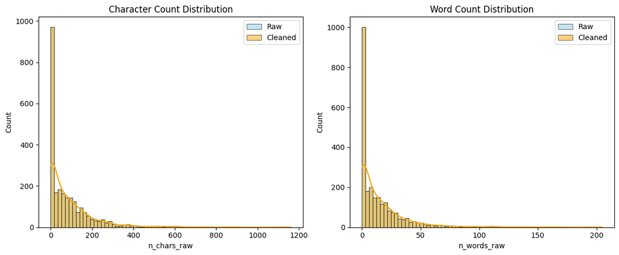

```
Top 5 rows with most characters removed:
```

|  | text_en_raw | text_en_clean | char_diff |
| --- | --- | --- | --- |
| 648 | Excellent place! Gloria is so sweet! She wen... | excellent place! gloria is so sweet! she went ... | 11 |
| 1809 | Great little coffee shop. Very nice staff, gr... | great little coffee shop. very nice staff, gre... | 5 |
| 967 | Avocado toast with sprouts, hard-boiled egg, a... | avocado toast with sprouts, hard-boiled egg, a... | 4 |
| 1374 | Great breakfast place. Open early as many plac... | great breakfast place. open early as many plac... | 4 |
| 1752 | Absolutely delicious coffee and bakery items. ... | absolutely delicious coffee and bakery items. ... | 4 |
| 2346 | 1 coffee, 1 cocoa drink, 2 slices of toast wit... | 1 coffee, 1 cocoa drink, 2 slices of toast wit... | 4 |
| 9 | Solely rating the coffee.\nI tend to order a c... | solely rating the coffee.\ni tend to order a c... | 3 |
| 567 | Just spent 10 days in Madrid and, after trying... | just spent 10 days in madrid and, after trying... | 3 |
| 581 | It's not worth it.\nThe price is high, and the... | it's not worth it.\nthe price is high, and the... | 3 |
| 2297 | We had a great experience!\n\nWe came by a cou... | we had a great experience!\nwe came by a coupl... | 3 |

```python
# OLD VERSION - BEFORE 12-01-2026
# 1. Calculate BEFORE metrics
df["n_chars_raw"] = df["text_en_raw"].fillna("").str.len()
df["n_words_raw"] = df["text_en_raw"].fillna("").str.split().str.len()

# 2. Run the normalization
df["text_en_clean"] = df["text_en_raw"].apply(normalize_text_textacy)

# 3. Calculate AFTER metrics
df["n_chars"] = df["text_en_clean"].fillna("").str.len()
df["n_words"] = df["text_en_clean"].fillna("").str.split().str.len()
df["is_short"] = df["n_words"] < 5

# 4. IMPACT ANALYSIS: Statistical Comparison
print("--- Text Normalization Impact Summary ---")
comparison_cols = ["n_chars_raw", "n_chars", "n_words_raw", "n_words"]
display(df[comparison_cols].describe().round(2))

# 5. IMPACT ANALYSIS: Visual Comparison
import matplotlib.pyplot as plt
import seaborn as sns

plt.figure(figsize=(12, 5))

plt.subplot(1, 2, 1)
sns.histplot(df["n_chars_raw"], color="skyblue", label="Raw", kde=True)
sns.histplot(df["n_chars"], color="orange", label="Cleaned", kde=True)
plt.title("Character Count Distribution")
plt.legend()

plt.subplot(1, 2, 2)
sns.histplot(df["n_words_raw"], color="skyblue", label="Raw", kde=True)
sns.histplot(df["n_words"], color="orange", label="Cleaned", kde=True)
plt.title("Word Count Distribution")
plt.legend()

plt.tight_layout()
plt.show()

# 6. Sample of Most Changed Rows
df['char_diff'] = df['n_chars_raw'] - df['n_chars']
print("\nTop 5 rows with most characters removed:")
display(df.nlargest(10, 'char_diff')[['text_en_raw', 'text_en_clean', 'char_diff']])
```

```python
df.head()
```

|  | createTime | starRating | review_clean | star_num | sentiment_3way | year | month | day | dayofweek | hour | year_month | text_en_raw | n_chars_raw | n_words_raw | text_en_clean | n_chars | n_words | is_short | char_diff |
| --- | --- | --- | --- | --- | --- | --- | --- | --- | --- | --- | --- | --- | --- | --- | --- | --- | --- | --- | --- |
| 0 | 2018-02-24 16:23:44.530000+00:00 | FIVE | (Translated by Google) Very welcoming place wi... | 5 | pos | 2018 | 2 | 24 | 5 | 16 | 2018-02 | Very welcoming place with quality products at ... | 101 | 17 | very welcoming place with quality products at ... | 101 | 17 | False | 0 |
| 1 | 2019-09-29 18:47:10.530323+00:00 | FIVE | (Translated by Google) We stopped by for coffe... | 5 | pos | 2019 | 9 | 29 | 6 | 18 | 2019-09 | We stopped by for coffee. We were several frie... | 140 | 26 | we stopped by for coffee. we were several frie... | 140 | 26 | False | 0 |
| 2 | 2019-09-24 19:01:11.659349+00:00 | FOUR | NaN | 4 | pos | 2019 | 9 | 24 | 1 | 19 | 2019-09 | NaN | 0 | 0 | NaN | 0 | 0 | True | 0 |
| 3 | 2019-09-23 17:26:48.376177+00:00 | FOUR | Good coffee and cake, but heavy traffic an arm... | 4 | pos | 2019 | 9 | 23 | 0 | 17 | 2019-09 | Good coffee and cake, but heavy traffic an arm... | 75 | 14 | good coffee and cake, but heavy traffic an arm... | 75 | 14 | False | 0 |
| 4 | 2019-09-15 15:50:20.745042+00:00 | FOUR | (Translated by Google) Good place for breakfas... | 4 | pos | 2019 | 9 | 15 | 6 | 15 | 2019-09 | Good place for breakfast, although the prices ... | 77 | 13 | good place for breakfast, although the prices ... | 77 | 13 | False | 0 |

```python
!pip install emoji
```

```
Downloading emoji-2.15.0-py3-none-any.whl (608 kB)
   ━━━━━━━━━━━━━━━━━━━━━━━━━━━━━━━━━━━━━━━━ 608.4/608.4 kB 9.9 MB/s eta 0:00:00
```

```
On average, preserving emojis added 0.29 words per review.
```

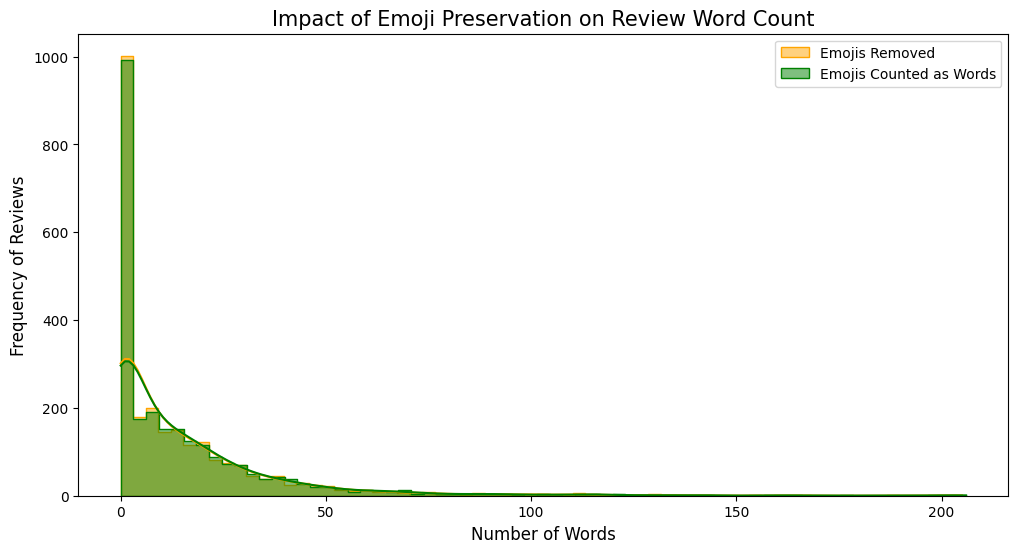

```
Example of Emoji Preservation:
```

|  | text_en_raw | text_en_clean | text_en_with_emoji |
| --- | --- | --- | --- |
| 9 | Solely rating the coffee.\nI tend to order a c... | solely rating the coffee.\ni tend to order a c... | solely rating the coffee. i tend to order a ca... |
| 25 | Delicious breakfasts in a peaceful atmosphere.... | delicious breakfasts in a peaceful atmosphere.... | delicious breakfasts in a peaceful atmosphere.... |
| 28 | A good option for tourists, it's a café filled... | a good option for tourists, it's a cafe filled... | a good option for tourists, it's a caf filled ... |
| 39 | The café is well located, the chairs are comfo... | the cafe is well located, the chairs are comfo... | the caf is well located, the chairs are comfor... |
| 40 | Gluten free bread for 1 € extra. The bread was... | gluten free bread for 1 € extra. the bread was... | gluten free bread for 1 extra. the bread was s... |
| 88 | A very cool café with views of the CaixaForum ... | a very cool cafe with views of the caixaforum ... | a very cool caf with views of the caixaforum m... |
| 100 | A truly delightful café! The waitresses are ve... | a truly delightful cafe! the waitresses are ve... | a truly delightful caf ! the waitresses are ve... |
| 108 | One of the best coffee shops in Madrid! Locate... | one of the best coffee shops in madrid! locate... | one of the best coffee shops in madrid! locate... |
| 115 | This is the best café in Madrid! Their chai la... | this is the best cafe in madrid! their chai la... | this is the best caf in madrid! their chai lat... |
| 118 | The wonderful, gorgeous girls\nA kiss from Mar... | the wonderful, gorgeous girls\na kiss from mar... | the wonderful, gorgeous girls a kiss from mar ... |
| 120 | For its location, the prices are very reasonab... | for its location, the prices are very reasonab... | for its location, the prices are very reasonab... |
| 131 | The place is cool, with a calm atmosphere, and... | the place is cool, with a calm atmosphere, and... | the place is cool, with a calm atmosphere, and... |
| 132 | It's expensive (the price-quality ratio leaves... | it's expensive (the price-quality ratio leaves... | it's expensive the price quality ratio leaves ... |
| 133 | Wonderful. The cakes are perfect. I love every... | wonderful. the cakes are perfect. i love every... | wonderful. the cakes are perfect. i love every... |
| 144 | The place is nice, but they charged us €11 for... | the place is nice, but they charged us €11 for... | the place is nice, but they charged us 11 for ... |
| 152 | 📍 El Patio Vertical: a cafe in the center of M... | 📍 el patio vertical: a cafe in the center of m... | round pushpin el patio vertical: a cafe in the... |
| 163 | The best chai latte I've ever had! I hope my T... | the best chai latte i've ever had! i hope my t... | the best chai latte i've ever had! i hope my t... |
| 166 | I went yesterday\nTo meet Wal Barros and I lov... | i went yesterday\nto meet wal barros and i lov... | i went yesterday to meet wal barros and i love... |
| 181 | A quiet and pleasant café. Ideal for sipping c... | a quiet and pleasant cafe. ideal for sipping c... | a quiet and pleasant caf . ideal for sipping c... |
| 186 | A café very close to Puerta del Sol with a wid... | a cafe very close to puerta del sol with a wid... | a caf very close to puerta del sol with a wide... |
| 200 | We had a snack in a café with a very special, ... | we had a snack in a cafe with a very special, ... | we had a snack in a caf with a very special, c... |
| 207 | A 10-star experience! Their sandwiches were sp... | a 10-star experience! their sandwiches were sp... | a 10 star experience! their sandwiches were sp... |
| 223 | A cozy café located next to the CaixaForum in ... | a cozy cafe located next to the caixaforum in ... | a cozy caf located next to the caixaforum in m... |
| 277 | Excellent atmosphere and incredible service! I... | excellent atmosphere and incredible service! i... | excellent atmosphere and incredible service! i... |
| 285 | The coffee shop with the best atmosphere in Ma... | the coffee shop with the best atmosphere in ma... | the coffee shop with the best atmosphere in ma... |
| 286 | 🫶🏻☕️Breakfast served with 120% love ☕️🫶🏿\n\nIt... | 🫶🏻☕️breakfast served with 120% love ☕️🫶🏿\nit w... | heart hands light skin tone hot beverage break... |
| 292 | Recommended! ⭐️⭐️⭐️⭐️⭐️ The best matcha tea in... | recommended! ⭐️⭐️⭐️⭐️⭐️ the best matcha tea in... | recommended! star star star star star the best... |
| 298 | Friendly staff. English menus. Good food. It’s... | friendly staff. english menus. good food. it’s... | friendly staff. english menus. good food. it s... |
| 301 | 8 euros for two doubles, we're crazy 💀 | 8 euros for two doubles, we're crazy 💀 | 8 euros for two doubles, we're crazy skull |
| 308 | A very well-located little café with an extrem... | a very well-located little cafe with an extrem... | a very well located little caf with an extreme... |
| 309 | The food was delicious! ♥️ and the service was... | the food was delicious! ♥️ and the service was... | the food was delicious! heart suit and the ser... |
| 314 | One of the best cafes in Madrid 😍 just 10 minu... | one of the best cafes in madrid 😍 just 10 minu... | one of the best cafes in madrid smiling face w... |
| 335 | A cozy, quiet place with a relaxed atmosphere,... | a cozy, quiet place with a relaxed atmosphere,... | a cozy, quiet place with a relaxed atmosphere,... |
| 345 | Excellent 😍 | excellent 😍 | excellent smiling face with heart eyes |
| 367 | I love the place, the service and everything 😁 | i love the place, the service and everything 😁 | i love the place, the service and everything b... |
| 411 | It's quite nice, expensive, but with good qual... | it's quite nice, expensive, but with good qual... | it's quite nice, expensive, but with good qual... |
| 425 | Great coffee and snacks. Near the Prado museum... | great coffee and snacks. near the prado museum... | great coffee and snacks. near the prado museum... |
| 451 | A very nice café, perfect for a snack, a coffe... | a very nice cafe, perfect for a snack, a coffe... | a very nice caf , perfect for a snack, a coffe... |
| 466 | Did not know how to make a cortado — just dump... | did not know how to make a cortado — just dump... | did not know how to make a cortado just dumped... |
| 467 | Passing through Atocha station, we stopped at ... | passing through atocha station, we stopped at ... | passing through atocha station, we stopped at ... |
| 474 | During my abroad semester, I came regularly. T... | during my abroad semester, i came regularly. t... | during my abroad semester, i came regularly. t... |
| 475 | I ordered a tomato and olive oil toast—very ta... | i ordered a tomato and olive oil toast—very ta... | i ordered a tomato and olive oil toast very ta... |
| 492 | This is my favorite cafe in Madrid! The staff ... | this is my favorite cafe in madrid! the staff ... | this is my favorite cafe in madrid! the staff ... |
| 506 | Great small Cafè. Have good prices and good fo... | great small cafe. have good prices and good fo... | great small caf . have good prices and good fo... |
| 508 | A small, almost hidden café next to the Caixa ... | a small, almost hidden cafe next to the caixa ... | a small, almost hidden caf next to the caixa f... |
| 542 | The best team ever! They're so kind and awesom... | the best team ever! they're so kind and awesom... | the best team ever! they're so kind and awesom... |
| 546 | Very nice place!!! Small but food is good and ... | very nice place!!! small but food is good and ... | very nice place!!! small but food is good and ... |
| 558 | Bad and very expensive coffee. €2.60 for a reg... | bad and very expensive coffee. €2.60 for a reg... | bad and very expensive coffee. 2.60 for a regu... |
| 572 | Nice cafe with a very good location (near the ... | nice cafe with a very good location (near the ... | nice cafe with a very good location near the p... |
| 576 | It's supposed to be a café, and the coffee the... | it's supposed to be a cafe, and the coffee the... | it's supposed to be a caf , and the coffee the... |

```python
# VERSION 13-01-2026 AT 10:15PM
import emoji
import pandas as pd
import re
import matplotlib.pyplot as plt
import seaborn as sns

def normalize_with_emoji_logic(text, keep_as_text=True):
    if pd.isna(text):
        return ""

    # 1. Handle Emojis
    if keep_as_text:
        # Convert 😋 to :face_savoring_food:
        text = emoji.demojize(text, delimiters=(" ", " "))

    # 2. Basic Cleaning (Standardize to lowercase)
    text = text.lower()

    # 3. Remove URLs/Emails
    text = re.sub(r"http\S+|www\.\S+", " URL ", text)
    text = re.sub(r"\S+@\S+", " EMAIL ", text)

    # 4. Clean symbols but KEEP the emoji text (which is now alphanumeric like :smile:)
    # We allow colons ":" temporarily so emoji tags survive
    text = re.sub(r"[^a-z0-9\s\.\,\!\?\':]", " ", text)

    # 5. Collapse whitespace
    text = re.sub(r"\s+", " ", text).strip()
    return text

# --- Step 1: Generate the new 'Emoji-Preserved' column ---
df["text_en_with_emoji"] = df["text_en_raw"].apply(lambda x: normalize_with_emoji_logic(x, keep_as_text=True))

# --- Step 2: Calculate word counts ---
# n_words was your count with emojis REMOVED
df["n_words_with_emoji"] = df["text_en_with_emoji"].str.split().str.len()

# --- Step 3: Visualization ---
plt.figure(figsize=(12, 6))

# Plot the distribution of the two cleaning methods
sns.histplot(df["n_words"], color="orange", label="Emojis Removed", kde=True, element="step", alpha=0.5)
sns.histplot(df["n_words_with_emoji"], color="green", label="Emojis Counted as Words", kde=True, element="step", alpha=0.5)

plt.title("Impact of Emoji Preservation on Review Word Count", fontsize=15)
plt.xlabel("Number of Words", fontsize=12)
plt.ylabel("Frequency of Reviews", fontsize=12)
plt.legend()

# Highlight the difference
avg_diff = df["n_words_with_emoji"].mean() - df["n_words"].mean()
print(f"On average, preserving emojis added {avg_diff:.2f} words per review.")

plt.show()

# --- Step 4: Show Example ---
print("\nExample of Emoji Preservation:")
sample = df[df["text_en_raw"].str.contains(r'[^\x00-\x7F]+', na=False)].head(50)
display(sample[['text_en_raw', 'text_en_clean', 'text_en_with_emoji']])
```

```python
# OLD VERSION - BEFORE 12-01-2026
#def normalize_text(text):
#    if pd.isna(text):
#        return np.nan
#    # Lowercase
#    text = text.lower()
#
    # Remove accents
#    text = unicodedata.normalize("NFKD", text)
#    text = "".join([c for c in text if not unicodedata.combining(c)])

    # Replace URLs and emails
#    text = re.sub(r"http\S+|www\.\S+", " URL ", text)
#    text = re.sub(r"\S+@\S+", " EMAIL ", text)

    # Keep letters, digits, basic punctuation; remove other symbols/emojis
#    text = re.sub(r"[^a-z0-9\s\.\,\!\?\']", " ", text)

    # Collapse whitespace
#    text = re.sub(r"\s+", " ", text).strip()
#    return text
```

```python
df.tail()
```

|  | createTime | starRating | review_clean | star_num | sentiment_3way | year | month | day | dayofweek | hour | ... | text_en_raw | n_chars_raw | n_words_raw | text_en_clean | n_chars | n_words | is_short | char_diff | text_en_with_emoji | n_words_with_emoji |
| --- | --- | --- | --- | --- | --- | --- | --- | --- | --- | --- | --- | --- | --- | --- | --- | --- | --- | --- | --- | --- | --- |
| 2505 | 2025-10-16 20:02:51.675736+00:00 | FIVE | (Translated by Google) Very comfortable, good ... | 5 | pos | 2025 | 10 | 16 | 3 | 20 | ... | Very comfortable, good treatment | 32 | 4 | very comfortable, good treatment | 32 | 4 | True | 0 | very comfortable, good treatment | 4 |
| 2506 | 2025-10-16 07:09:26.980652+00:00 | FIVE | (Translated by Google) The best coffee! If you... | 5 | pos | 2025 | 10 | 16 | 3 | 7 | ... | The best coffee! If you want an extra-large co... | 73 | 14 | the best coffee! if you want an extra-large co... | 73 | 14 | False | 0 | the best coffee! if you want an extra large co... | 16 |
| 2507 | 2025-10-14 09:06:26.383063+00:00 | FIVE | (Translated by Google) Breakfast with ham, ver... | 5 | pos | 2025 | 10 | 14 | 1 | 9 | ... | Breakfast with ham, very good, recommended qua... | 56 | 7 | breakfast with ham, very good, recommended qua... | 56 | 7 | False | 0 | breakfast with ham, very good, recommended qua... | 8 |
| 2508 | 2025-10-14 09:04:45.542688+00:00 | FIVE | (Translated by Google) Phenomenal exquisite br... | 5 | pos | 2025 | 10 | 14 | 1 | 9 | ... | Phenomenal exquisite breakfasts🥰🥰🥰 | 34 | 3 | phenomenal exquisite breakfasts🥰🥰🥰 | 34 | 3 | True | 0 | phenomenal exquisite breakfasts smiling face w... | 15 |
| 2509 | 2025-10-13 09:32:46.028701+00:00 | FIVE | Love this place. Stop for breakfast every sing... | 5 | pos | 2025 | 10 | 13 | 0 | 9 | ... | Love this place. Stop for breakfast every sing... | 199 | 32 | love this place. stop for breakfast every sing... | 199 | 32 | False | 0 | love this place. stop for breakfast every sing... | 32 |

5 rows × 21 columns

#### Step 6 – Drop empty texts, keep short ones

```python
df.shape
```

```
(2508, 21)
```

```python
# 1. Capture "BEFORE" state
rows_before = len(df)
dist_before = df['starRating'].value_counts(normalize=True).sort_index()

# 2. Identify what will be dropped (for inspection) where cleaned text is empty or NaN
mask_nonempty = df["text_en_with_emoji"].notna() & (df["text_en_with_emoji"].str.strip() != "")

# 3. Apply the filter
df = df[mask_nonempty].copy()

# 4. Capture "AFTER" state
rows_after = len(df)
dist_after = df['starRating'].value_counts(normalize=True).sort_index()

# --- IMPACT REPORT ---
print(f"--- FILTERING IMPACT REPORT ---")
print(f"Rows Before: {rows_before}")
print(f"Rows After:  {rows_after}")
print(f"Total Rows Dropped: {rows_before - rows_after} ({(1 - rows_after/rows_before)*100:.2f}%)")

# 5. Check for Sentiment Bias
# We compare the percentage of each star rating before and after to see if it changed
comparison_df = pd.DataFrame({
    'Before (%)': dist_before * 100,
    'After (%)': dist_after * 100
})
comparison_df['Shift (pp)'] = comparison_df['After (%)'] - comparison_df['Before (%)']

print("\nDistribution Shift (Are we losing specific ratings?):")
display(comparison_df.round(2))

# 6. Inspect what was lost
if len(df) > 0:
    print("\nSample of dropped rows (Raw text that became empty/NaN):")
    display(df[['text_en_raw', 'starRating']].head(5))
```

```
--- FILTERING IMPACT REPORT ---
Rows Before: 2508
Rows After:  1632
Total Rows Dropped: 876 (34.93%)

Distribution Shift (Are we losing specific ratings?):
```

| starRating | Before (%) | After (%) | Shift (pp) |
| --- | --- | --- | --- |
| FIVE | 63.32 | 66.91 | 3.59 |
| FOUR | 19.78 | 16.42 | -3.36 |
| ONE | 4.51 | 5.76 | 1.25 |
| THREE | 9.05 | 7.48 | -1.58 |
| TWO | 3.35 | 3.43 | 0.08 |

```
Sample of dropped rows (Raw text that became empty/NaN):
```

|  | text_en_raw | starRating |
| --- | --- | --- |
| 0 | Very welcoming place with quality products at ... | FIVE |
| 1 | We stopped by for coffee. We were several frie... | FIVE |
| 3 | Good coffee and cake, but heavy traffic an arm... | FOUR |
| 4 | Good place for breakfast, although the prices ... | FOUR |
| 6 | Fantastic place and the attention of the staff... | FIVE |

#### Step 7 – Light, sentiment‑aware stopwords + lemmatization

```python
import spacy

# In shell beforehand: python -m spacy download en_core_web_sm
nlp = spacy.load("en_core_web_sm", disable=["parser"])

# Start from spaCy English stopwords
stopwords = nlp.Defaults.stop_words.copy()

# Keep negation and intensity words
to_keep = {"no", "not", "never", "none", "very", "too", "so", "quite"}
stopwords = {w for w in stopwords if w not in to_keep}

def lemmatize_and_filter(doc):
    lemmas = []
    for token in doc:
        if token.is_space:
            continue
        # Skip punctuation, numbers as desired
        if token.is_punct:
            continue
        lemma = token.lemma_.lower()
        if lemma in stopwords:
            continue
        if not lemma.isalpha():
            continue
        lemmas.append(lemma)
    return " ".join(lemmas)

def preprocess_text_spacy(text):
    if pd.isna(text):
        return ""
    doc = nlp(text)
    return lemmatize_and_filter(doc)

# Apply to create final text field for modeling
#df["text_final"] = df["text_en_with_emoji"].apply(preprocess_text_spacy)
```

```python
import time
from collections import Counter

# 1. Capture BEFORE metrics
df["n_words_pre_spacy"] = df["text_en_with_emoji"].fillna("").str.split().str.len()
all_words_pre = " ".join(df["text_en_with_emoji"].fillna("")).split()
vocab_size_pre = len(set(all_words_pre))

# 2. Run the spaCy process (Tracking time as it can be slow)
print(f"Starting spaCy preprocessing on {len(df)} rows...")
start_time = time.time()
df["text_final"] = df["text_en_with_emoji"].apply(preprocess_text_spacy)
end_time = time.time()

# 3. Capture AFTER metrics
df["n_words_final"] = df["text_final"].fillna("").str.split().str.len()
all_words_final = " ".join(df["text_final"].fillna("")).split()
vocab_size_final = len(set(all_words_final))

# 4. IMPACT REPORT
print(f"\n--- spaCy Preprocessing Impact Report ---")
print(f"Processing Time: {end_time - start_time:.2f} seconds")
print(f"Total Words (Before): {len(all_words_pre)}")
print(f"Total Words (After):  {len(all_words_final)}")
print(f"Word Reduction:      {((len(all_words_pre) - len(all_words_final)) / len(all_words_pre)) * 100:.2f}%")

print(f"\nVocabulary Size (Before): {vocab_size_pre} unique words")
print(f"Vocabulary Size (After):  {vocab_size_final} unique words")
print(f"Vocab Compression:        {((vocab_size_pre - vocab_size_final) / vocab_size_pre) * 100:.2f}%")

# 5. Qualitative Check: See the transformation
print("\nTransformation Examples (Cleaned -> Final):")
display(df[['text_en_clean', 'text_final']].head(5))

# 6. Check Top 10 Words (Before vs After)
top_10_pre = Counter(all_words_pre).most_common(10)
top_10_after = Counter(all_words_final).most_common(10)

print("\nTop 10 Most Frequent Words:")
compare_words = pd.DataFrame({
    'Before (Noisy)': [f"{w} ({c})" for w, c in top_10_pre],
    'After (Lemmatized)': [f"{w} ({c})" for w, c in top_10_after]
})
display(compare_words)
```

```
Starting spaCy preprocessing on 1632 rows...

--- spaCy Preprocessing Impact Report ---
Processing Time: 29.14 seconds
Total Words (Before): 38090
Total Words (After):  19532
Word Reduction:      48.72%

Vocabulary Size (Before): 4446 unique words
Vocabulary Size (After):  2134 unique words
Vocab Compression:        52.00%

Transformation Examples (Cleaned -> Final):
```

|  | text_en_clean | text_final |
| --- | --- | --- |
| 0 | very welcoming place with quality products at ... | very welcome place quality product great price... |
| 1 | we stopped by for coffee. we were several frie... | stop coffee friend table large group very good... |
| 3 | good coffee and cake, but heavy traffic an arm... | good coffee cake heavy traffic arm length away... |
| 4 | good place for breakfast, although the prices ... | good place breakfast price bit high friendly s... |
| 6 | fantastic place and the attention of the staff... | fantastic place attention staff highly recomme... |

```
Top 10 Most Frequent Words:
```

|  | Before (Noisy) | After (Lemmatized) |
| --- | --- | --- |
| 0 | the (2278) | very (865) |
| 1 | and (2001) | good (725) |
| 2 | a (1382) | coffee (699) |
| 3 | very (858) | place (586) |
| 4 | is (694) | service (511) |
| 5 | to (692) | delicious (364) |
| 6 | i (619) | not (355) |
| 7 | was (562) | breakfast (313) |
| 8 | for (518) | friendly (308) |
| 9 | good (511) | great (280) |

```python
# Show selected columns
selected_columns = ['text_final','text_en_with_emoji']
df[selected_columns].tail()
```

|  | text_final | text_en_with_emoji |
| --- | --- | --- |
| 2505 | very comfortable good treatment | very comfortable, good treatment |
| 2506 | good coffee want extra large coffee place face... | the best coffee! if you want an extra large co... |
| 2507 | breakfast ham very good recommend quality price | breakfast with ham, very good, recommended qua... |
| 2508 | phenomenal exquisite breakfast smile face hear... | phenomenal exquisite breakfasts smiling face w... |
| 2509 | love place stop breakfast single time visit ma... | love this place. stop for breakfast every sing... |

##### Saving the cleaned dataframe to .tsv file

```python
# Create the Review_ID column from the current dataframe index
df['Review_ID'] = df.index

# Selecting columns createTime, starRating, star_num, sentiment_3way, year, month, day, dayofweek, text_en_with_emoji, n_words_with_emoji
selected_columns = ['Review_ID', 'createTime', 'starRating', 'star_num', 'sentiment_3way', 'year', 'month', 'day', 'dayofweek', 'text_en_clean', 'text_en_with_emoji', 'n_words_with_emoji']
df_cleaned_reviews = df[selected_columns]

# Saving df to cleaned_df.tsv
df_cleaned_reviews.to_csv('cleaned_reviews_df_v20260114_2016PM.tsv', sep='\t', index=False)
```

#### Step 8 - Clustering the Comments and StarRatings

The Best Strategy for your Dataset Because you have a mix of sentiment labels and text, here is the recommended 3-step workflow:

Vectorize the Text: Turn text_en_with_emoji into numbers using TF-IDF (which weights unique words like "breakfast" or "smiling_face" highly).

Encode Sentiment: Turn pos, neu, neg into numeric columns.

Clustering: Use K-Means (simplest) or DBSCAN to find the groups.

```python
from sklearn.feature_extraction.text import TfidfVectorizer
from sklearn.cluster import KMeans
from sklearn.preprocessing import OneHotEncoder
import scipy.sparse as sp

# 1. Vectorize the Text (TF-IDF)
# We use max_features=500 to keep it efficient
tfidf = TfidfVectorizer(max_features=500, stop_words='english')
text_vectors = tfidf.fit_transform(df['text_en_with_emoji'])

# 2. Encode Sentiment (One-Hot Encoding)
# This turns 'pos' into [1, 0, 0], 'neu' into [0, 1, 0], etc.
encoder = OneHotEncoder()
sentiment_vectors = encoder.fit_transform(df[['sentiment_3way']])

# 3. Combine Text and Sentiment features
combined_features = sp.hstack((text_vectors, sentiment_vectors))

# 4. Run K-Means Clustering
# Let's start with N clusters (you can change this number)
num_clusters = 4
kmeans = KMeans(n_clusters=num_clusters, random_state=42, n_init=10)
df['cluster'] = kmeans.fit_predict(combined_features)

print(f"Clustering complete! {num_clusters} groups identified.")
```

```
Clustering complete! 4 groups identified.
```

```python
import numpy as np

# Function to show top words per cluster
def get_top_keywords(n_terms):
    df_clusters = pd.DataFrame(combined_features.todense()).groupby(df['cluster'].values).mean()
    terms = tfidf.get_feature_names_out()

    # Add sentiment names to terms list to correctly map all combined features
    terms = list(terms) + list(encoder.get_feature_names_out())

    for i, r in df_clusters.iterrows():
        print(f"\nCluster {i}:")
        print(", ".join([terms[t] for t in np.argsort(r)[:-(n_terms+1):-1]]))


get_top_keywords(10)
```

```
Cluster 0:
sentiment_3way_pos, place, delicious, coffee, excellent, great, service, friendly, nice, staff

Cluster 1:
sentiment_3way_neu, good, coffee, expensive, place, nice, bit, small, service, breakfast

Cluster 2:
sentiment_3way_pos, good, service, coffee, place, breakfast, excellent, food, nice, friendly

Cluster 3:
sentiment_3way_neg, expensive, coffee, bad, euros, like, didn, terrible, don, service
```

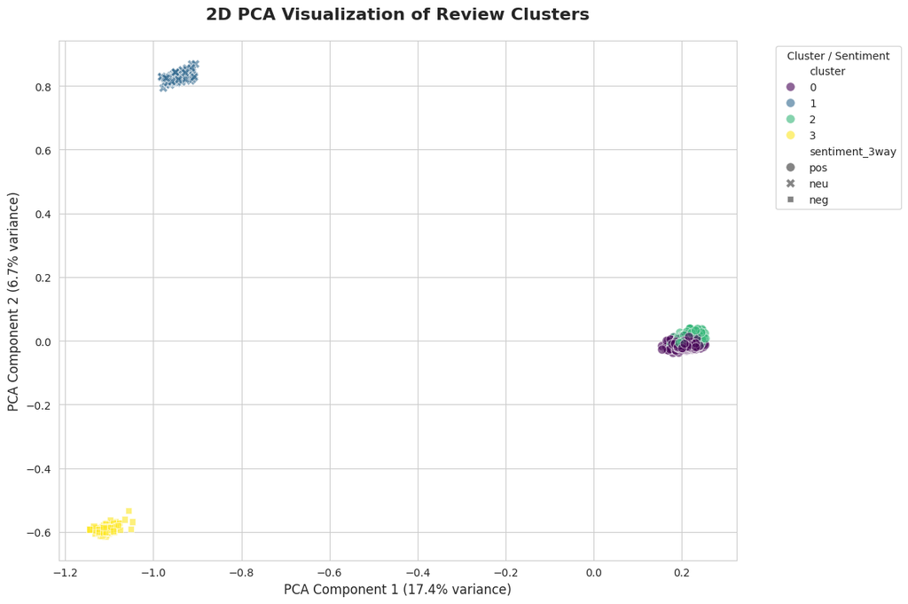

```python
# Visualizing

from sklearn.decomposition import PCA
import matplotlib.pyplot as plt
import seaborn as sns

# 1. Initialize PCA to reduce data to 2 dimensions
pca = PCA(n_components=2, random_state=42)

# 2. Transform the combined features (TF-IDF + Sentiment)
# We use .toarray() because PCA requires a dense matrix
pca_data = pca.fit_transform(combined_features.toarray())

# 3. Add the PCA coordinates to your DataFrame
df['pca_x'] = pca_data[:, 0]
df['pca_y'] = pca_data[:, 1]

# 4. Create the Plot
plt.figure(figsize=(12, 8))
sns.set_style("whitegrid")

# We use 'hue' for the clusters and 'style' for the sentiment
# This allows you to see if the clusters are purely topic-based or sentiment-based
scatter = sns.scatterplot(
    data=df,
    x='pca_x',
    y='pca_y',
    hue='cluster',
    style='sentiment_3way',
    palette='viridis',
    s=70,
    alpha=0.6,
    edgecolor='w'
)

# 5. Add Titles and Labels
plt.title("2D PCA Visualization of Review Clusters", fontsize=16, fontweight='bold', pad=20)
plt.xlabel(f"PCA Component 1 ({pca.explained_variance_ratio_[0]:.1%} variance)", fontsize=12)
plt.ylabel(f"PCA Component 2 ({pca.explained_variance_ratio_[1]:.1%} variance)", fontsize=12)

# Move legend outside to keep the plot clean
plt.legend(title="Cluster / Sentiment", bbox_to_anchor=(1.05, 1), loc='upper left')

plt.tight_layout()
plt.show()
```

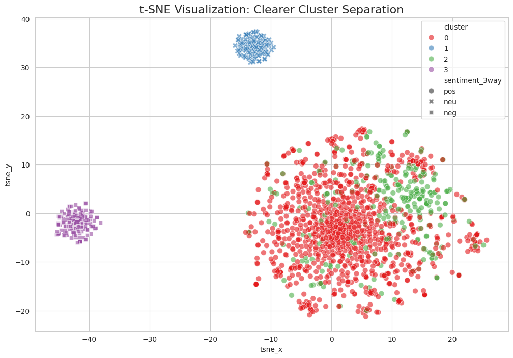

```
Cluster 0:
sentiment_3way_pos, place, delicious, coffee, excellent, great, service, friendly, nice, staff, breakfast, food

Cluster 1:
sentiment_3way_neu, good, coffee, expensive, place, nice, bit, small, service, breakfast, location, toast

Cluster 2:
sentiment_3way_pos, good, service, coffee, place, breakfast, excellent, food, nice, friendly, cakes, prices

Cluster 3:
sentiment_3way_neg, expensive, coffee, bad, euros, like, didn, terrible, don, service, rude, good
```

```python
# Use t-SNE (The "Gold Standard" for Text Clusters)
from sklearn.manifold import TSNE

# 1. Run t-SNE (Note: this can take a minute if you have >5000 rows)
# We use the combined_features from your previous step
tsne = TSNE(n_components=2, perplexity=30, random_state=42, init='pca', learning_rate='auto')
tsne_data = tsne.fit_transform(combined_features.toarray())

df['tsne_x'] = tsne_data[:, 0]
df['tsne_y'] = tsne_data[:, 1]

# 2. Plot t-SNE
plt.figure(figsize=(12, 8))
sns.scatterplot(
    data=df,
    x='tsne_x', y='tsne_y',
    hue='cluster',
    style='sentiment_3way',
    palette='Set1', # High contrast colors
    s=60,
    alpha=0.6
)
plt.title("t-SNE Visualization: Clearer Cluster Separation", fontsize=16)
plt.show()

get_top_keywords(12)
```

#### Step 9 - Clustering just the negative reviews

```python
import numpy as np
from sklearn.feature_extraction.text import TfidfVectorizer
from sklearn.cluster import KMeans

# 1. Filter the dataframe for negative reviews only
df_neg = df[df['sentiment_3way'] == 'neg'].copy()

# 2. Vectorize the 'text_en_with_emoji' column
# We use TF-IDF to find the most meaningful words in these complaints
tfidf = TfidfVectorizer(
    max_features=1000,
    stop_words='english',
    ngram_range=(1, 2)  # This captures pairs like "cold food" or "long wait"
)

neg_vectors = tfidf.fit_transform(df_neg['text_en_with_emoji'])

# 3. Apply K-Means
# We'll try 3 clusters to see if we can find 3 distinct types of complaints
num_clusters = 3
kmeans = KMeans(n_clusters=num_clusters, random_state=42, n_init=10)
df_neg['neg_cluster'] = kmeans.fit_predict(neg_vectors)

print(f"Clustering complete for {len(df_neg)} negative reviews.")
```

```
Clustering complete for 150 negative reviews.
```

```python
# Analyze the "Complaint Clusters"
# Function to display the themes of each complaint cluster
def get_complaint_themes(n_terms=10):
    terms = tfidf.get_feature_names_out()

    for i in range(num_clusters):
        # FIX: We use .values to ensure we pass a numpy array to the sparse matrix
        mask = (df_neg['neg_cluster'] == i).values

        # Calculate the mean TF-IDF score for each word in this cluster
        center = neg_vectors[mask].mean(axis=0).A1

        # Get the indices of the highest scoring words
        top_indices = center.argsort()[::-1][:n_terms]

        print(f"\n🔴 COMPLAINT CLUSTER {i}:")
        # Ensure we don't try to access out-of-bounds indices
        top_words = [terms[t] for t in top_indices if center[t] > 0]
        print(", ".join(top_words))

get_complaint_themes()
```

```
🔴 COMPLAINT CLUSTER 0:
expensive, location, coffee, price, friendly, madrid, prices, toast, expensive price, milk

🔴 COMPLAINT CLUSTER 1:
service, rude, poor, euros, good, small, terrible, prices, little, food

🔴 COMPLAINT CLUSTER 2:
coffee, like, bad, place, don, table, didn, friendly, nice, people
```

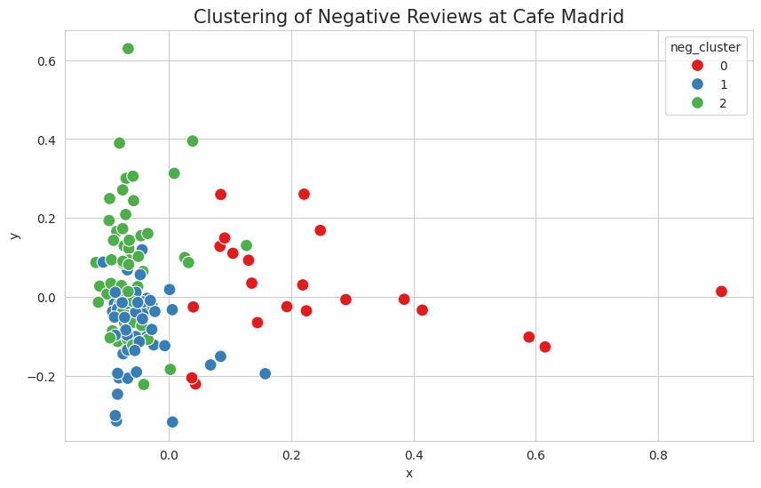

```python
#3. Visualizing the Clusters with PCA

from sklearn.decomposition import PCA
import seaborn as sns

# Reduce dimensions to 2D
pca = PCA(n_components=2, random_state=42)
coords = pca.fit_transform(neg_vectors.toarray())
df_neg['x'] = coords[:, 0]
df_neg['y'] = coords[:, 1]

# Plot
plt.figure(figsize=(10, 6))
sns.scatterplot(data=df_neg, x='x', y='y', hue='neg_cluster', palette='Set1', s=100)
plt.title("Clustering of Negative Reviews at Cafe Madrid", fontsize=15)
plt.show()
```